# Risk Factor Analysis

## Outcome Variable

**Outcome Variable:** pers_wast

## Predictor Variables

**Intervention Variable:** meducyrs

**Adjustment Set:**

unadjusted

## Stratifying Variables

The analysis was stratified on these variable(s):

- agecat
- studyid
- country

## Data Summary

| agecat | studyid | country | meducyrs | pers_wast | n_cell | n |
| --- | --- | --- | --- | --- | --- | --- |
| 0-24 months | ki0047075b-MAL-ED | BANGLADESH | High | 0 | 71 | 202 |
| 0-24 months | ki0047075b-MAL-ED | BANGLADESH | High | 1 | 4 | 202 |
| 0-24 months | ki0047075b-MAL-ED | BANGLADESH | Low | 0 | 62 | 202 |
| 0-24 months | ki0047075b-MAL-ED | BANGLADESH | Low | 1 | 4 | 202 |
| 0-24 months | ki0047075b-MAL-ED | BANGLADESH | Medium | 0 | 59 | 202 |
| 0-24 months | ki0047075b-MAL-ED | BANGLADESH | Medium | 1 | 2 | 202 |
| 0-24 months | ki0047075b-MAL-ED | BRAZIL | High | 0 | 74 | 216 |
| 0-24 months | ki0047075b-MAL-ED | BRAZIL | High | 1 | 0 | 216 |
| 0-24 months | ki0047075b-MAL-ED | BRAZIL | Low | 0 | 59 | 216 |
| 0-24 months | ki0047075b-MAL-ED | BRAZIL | Low | 1 | 1 | 216 |
| 0-24 months | ki0047075b-MAL-ED | BRAZIL | Medium | 0 | 81 | 216 |
| 0-24 months | ki0047075b-MAL-ED | BRAZIL | Medium | 1 | 1 | 216 |
| 0-24 months | ki0047075b-MAL-ED | INDIA | High | 0 | 56 | 210 |
| 0-24 months | ki0047075b-MAL-ED | INDIA | High | 1 | 4 | 210 |
| 0-24 months | ki0047075b-MAL-ED | INDIA | Low | 0 | 63 | 210 |
| 0-24 months | ki0047075b-MAL-ED | INDIA | Low | 1 | 10 | 210 |
| 0-24 months | ki0047075b-MAL-ED | INDIA | Medium | 0 | 72 | 210 |
| 0-24 months | ki0047075b-MAL-ED | INDIA | Medium | 1 | 5 | 210 |
| 0-24 months | ki0047075b-MAL-ED | NEPAL | High | 0 | 53 | 223 |
| 0-24 months | ki0047075b-MAL-ED | NEPAL | High | 1 | 0 | 223 |
| 0-24 months | ki0047075b-MAL-ED | NEPAL | Low | 0 | 93 | 223 |
| 0-24 months | ki0047075b-MAL-ED | NEPAL | Low | 1 | 1 | 223 |
| 0-24 months | ki0047075b-MAL-ED | NEPAL | Medium | 0 | 74 | 223 |
| 0-24 months | ki0047075b-MAL-ED | NEPAL | Medium | 1 | 2 | 223 |
| 0-24 months | ki0047075b-MAL-ED | PERU | High | 0 | 85 | 283 |
| 0-24 months | ki0047075b-MAL-ED | PERU | High | 1 | 0 | 283 |
| 0-24 months | ki0047075b-MAL-ED | PERU | Low | 0 | 98 | 283 |
| 0-24 months | ki0047075b-MAL-ED | PERU | Low | 1 | 0 | 283 |
| 0-24 months | ki0047075b-MAL-ED | PERU | Medium | 0 | 99 | 283 |
| 0-24 months | ki0047075b-MAL-ED | PERU | Medium | 1 | 1 | 283 |

[output cut: 396 more lines]

The following strata were considered:

- agecat: 0-24 months, studyid: ki0047075b-MAL-ED, country: BANGLADESH
- agecat: 0-24 months, studyid: ki0047075b-MAL-ED, country: BRAZIL
- agecat: 0-24 months, studyid: ki0047075b-MAL-ED, country: INDIA
- agecat: 0-24 months, studyid: ki0047075b-MAL-ED, country: NEPAL
- agecat: 0-24 months, studyid: ki0047075b-MAL-ED, country: PERU
- agecat: 0-24 months, studyid: ki0047075b-MAL-ED, country: SOUTH AFRICA
- agecat: 0-24 months, studyid: ki0047075b-MAL-ED, country: TANZANIA, UNITED REPUBLIC OF
- agecat: 0-24 months, studyid: ki1000108-CMC-V-BCS-2002, country: INDIA
- agecat: 0-24 months, studyid: ki1000108-IRC, country: INDIA
- agecat: 0-24 months, studyid: ki1000109-EE, country: PAKISTAN
- agecat: 0-24 months, studyid: ki1000304b-SAS-CompFeed, country: INDIA
- agecat: 0-24 months, studyid: ki1000304b-SAS-FoodSuppl, country: INDIA
- agecat: 0-24 months, studyid: ki1017093-NIH-Birth, country: BANGLADESH
- agecat: 0-24 months, studyid: ki1017093b-PROVIDE, country: BANGLADESH
- agecat: 0-24 months, studyid: ki1017093c-NIH-Crypto, country: BANGLADESH
- agecat: 0-24 months, studyid: ki1066203-TanzaniaChild2, country: TANZANIA, UNITED REPUBLIC OF
- agecat: 0-24 months, studyid: ki1112895-Guatemala BSC, country: GUATEMALA
- agecat: 0-24 months, studyid: ki1113344-GMS-Nepal, country: NEPAL
- agecat: 0-24 months, studyid: ki1119695-PROBIT, country: BELARUS
- agecat: 0-24 months, studyid: ki1126311-ZVITAMBO, country: ZIMBABWE
- agecat: 0-24 months, studyid: ki1135781-COHORTS, country: GUATEMALA
- agecat: 0-24 months, studyid: ki1135781-COHORTS, country: INDIA
- agecat: 0-24 months, studyid: ki1135781-COHORTS, country: PHILIPPINES
- agecat: 0-24 months, studyid: ki1148112-LCNI-5, country: MALAWI
- agecat: 0-24 months, studyid: kiGH5241-JiVitA-3, country: BANGLADESH
- agecat: 0-24 months, studyid: kiGH5241-JiVitA-4, country: BANGLADESH
- agecat: 0-6 months, studyid: ki0047075b-MAL-ED, country: BANGLADESH
- agecat: 0-6 months, studyid: ki0047075b-MAL-ED, country: BRAZIL
- agecat: 0-6 months, studyid: ki0047075b-MAL-ED, country: INDIA
- agecat: 0-6 months, studyid: ki0047075b-MAL-ED, country: NEPAL
- agecat: 0-6 months, studyid: ki0047075b-MAL-ED, country: PERU
- agecat: 0-6 months, studyid: ki0047075b-MAL-ED, country: SOUTH AFRICA
- agecat: 0-6 months, studyid: ki0047075b-MAL-ED, country: TANZANIA, UNITED REPUBLIC OF
- agecat: 0-6 months, studyid: ki1000108-CMC-V-BCS-2002, country: INDIA
- agecat: 0-6 months, studyid: ki1000108-IRC, country: INDIA
- agecat: 0-6 months, studyid: ki1000109-EE, country: PAKISTAN
- agecat: 0-6 months, studyid: ki1017093-NIH-Birth, country: BANGLADESH
- agecat: 0-6 months, studyid: ki1017093b-PROVIDE, country: BANGLADESH
- agecat: 0-6 months, studyid: ki1017093c-NIH-Crypto, country: BANGLADESH
- agecat: 0-6 months, studyid: ki1066203-TanzaniaChild2, country: TANZANIA, UNITED REPUBLIC OF
- agecat: 0-6 months, studyid: ki1113344-GMS-Nepal, country: NEPAL
- agecat: 0-6 months, studyid: ki1119695-PROBIT, country: BELARUS
- agecat: 0-6 months, studyid: ki1126311-ZVITAMBO, country: ZIMBABWE
- agecat: 0-6 months, studyid: ki1135781-COHORTS, country: PHILIPPINES
- agecat: 0-6 months, studyid: kiGH5241-JiVitA-3, country: BANGLADESH
- agecat: 6-24 months, studyid: ki0047075b-MAL-ED, country: BANGLADESH
- agecat: 6-24 months, studyid: ki0047075b-MAL-ED, country: BRAZIL
- agecat: 6-24 months, studyid: ki0047075b-MAL-ED, country: INDIA
- agecat: 6-24 months, studyid: ki0047075b-MAL-ED, country: NEPAL
- agecat: 6-24 months, studyid: ki0047075b-MAL-ED, country: PERU
- agecat: 6-24 months, studyid: ki0047075b-MAL-ED, country: SOUTH AFRICA
- agecat: 6-24 months, studyid: ki0047075b-MAL-ED, country: TANZANIA, UNITED REPUBLIC OF
- agecat: 6-24 months, studyid: ki1000108-CMC-V-BCS-2002, country: INDIA
- agecat: 6-24 months, studyid: ki1000108-IRC, country: INDIA
- agecat: 6-24 months, studyid: ki1000109-EE, country: PAKISTAN
- agecat: 6-24 months, studyid: ki1000304b-SAS-CompFeed, country: INDIA
- agecat: 6-24 months, studyid: ki1000304b-SAS-FoodSuppl, country: INDIA
- agecat: 6-24 months, studyid: ki1017093-NIH-Birth, country: BANGLADESH
- agecat: 6-24 months, studyid: ki1017093b-PROVIDE, country: BANGLADESH
- agecat: 6-24 months, studyid: ki1017093c-NIH-Crypto, country: BANGLADESH
- agecat: 6-24 months, studyid: ki1066203-TanzaniaChild2, country: TANZANIA, UNITED REPUBLIC OF
- agecat: 6-24 months, studyid: ki1112895-Guatemala BSC, country: GUATEMALA
- agecat: 6-24 months, studyid: ki1113344-GMS-Nepal, country: NEPAL
- agecat: 6-24 months, studyid: ki1119695-PROBIT, country: BELARUS
- agecat: 6-24 months, studyid: ki1126311-ZVITAMBO, country: ZIMBABWE
- agecat: 6-24 months, studyid: ki1135781-COHORTS, country: GUATEMALA
- agecat: 6-24 months, studyid: ki1135781-COHORTS, country: INDIA
- agecat: 6-24 months, studyid: ki1135781-COHORTS, country: PHILIPPINES
- agecat: 6-24 months, studyid: ki1148112-LCNI-5, country: MALAWI
- agecat: 6-24 months, studyid: kiGH5241-JiVitA-3, country: BANGLADESH
- agecat: 6-24 months, studyid: kiGH5241-JiVitA-4, country: BANGLADESH

### Dropped Strata

Some strata were dropped due to rare outcomes:

- agecat: 0-24 months, studyid: ki0047075b-MAL-ED, country: BANGLADESH
- agecat: 0-24 months, studyid: ki0047075b-MAL-ED, country: BRAZIL
- agecat: 0-24 months, studyid: ki0047075b-MAL-ED, country: INDIA
- agecat: 0-24 months, studyid: ki0047075b-MAL-ED, country: NEPAL
- agecat: 0-24 months, studyid: ki0047075b-MAL-ED, country: PERU
- agecat: 0-24 months, studyid: ki0047075b-MAL-ED, country: SOUTH AFRICA
- agecat: 0-24 months, studyid: ki0047075b-MAL-ED, country: TANZANIA, UNITED REPUBLIC OF
- agecat: 0-24 months, studyid: ki1000109-EE, country: PAKISTAN
- agecat: 0-24 months, studyid: ki1000304b-SAS-CompFeed, country: INDIA
- agecat: 0-24 months, studyid: ki1000304b-SAS-FoodSuppl, country: INDIA
- agecat: 0-24 months, studyid: ki1017093b-PROVIDE, country: BANGLADESH
- agecat: 0-24 months, studyid: ki1017093c-NIH-Crypto, country: BANGLADESH
- agecat: 0-24 months, studyid: ki1066203-TanzaniaChild2, country: TANZANIA, UNITED REPUBLIC OF
- agecat: 0-24 months, studyid: ki1112895-Guatemala BSC, country: GUATEMALA
- agecat: 0-24 months, studyid: ki1148112-LCNI-5, country: MALAWI
- agecat: 0-24 months, studyid: kiGH5241-JiVitA-4, country: BANGLADESH
- agecat: 0-6 months, studyid: ki0047075b-MAL-ED, country: BANGLADESH
- agecat: 0-6 months, studyid: ki0047075b-MAL-ED, country: BRAZIL
- agecat: 0-6 months, studyid: ki0047075b-MAL-ED, country: NEPAL
- agecat: 0-6 months, studyid: ki0047075b-MAL-ED, country: PERU
- agecat: 0-6 months, studyid: ki0047075b-MAL-ED, country: SOUTH AFRICA
- agecat: 0-6 months, studyid: ki0047075b-MAL-ED, country: TANZANIA, UNITED REPUBLIC OF
- agecat: 0-6 months, studyid: ki1000109-EE, country: PAKISTAN
- agecat: 0-6 months, studyid: ki1017093-NIH-Birth, country: BANGLADESH
- agecat: 0-6 months, studyid: ki1017093b-PROVIDE, country: BANGLADESH
- agecat: 0-6 months, studyid: ki1017093c-NIH-Crypto, country: BANGLADESH
- agecat: 0-6 months, studyid: ki1066203-TanzaniaChild2, country: TANZANIA, UNITED REPUBLIC OF
- agecat: 0-6 months, studyid: ki1126311-ZVITAMBO, country: ZIMBABWE
- agecat: 0-6 months, studyid: kiGH5241-JiVitA-3, country: BANGLADESH
- agecat: 6-24 months, studyid: ki0047075b-MAL-ED, country: BANGLADESH
- agecat: 6-24 months, studyid: ki0047075b-MAL-ED, country: BRAZIL
- agecat: 6-24 months, studyid: ki0047075b-MAL-ED, country: INDIA
- agecat: 6-24 months, studyid: ki0047075b-MAL-ED, country: NEPAL
- agecat: 6-24 months, studyid: ki0047075b-MAL-ED, country: PERU
- agecat: 6-24 months, studyid: ki0047075b-MAL-ED, country: SOUTH AFRICA
- agecat: 6-24 months, studyid: ki0047075b-MAL-ED, country: TANZANIA, UNITED REPUBLIC OF
- agecat: 6-24 months, studyid: ki1000109-EE, country: PAKISTAN
- agecat: 6-24 months, studyid: ki1000304b-SAS-CompFeed, country: INDIA
- agecat: 6-24 months, studyid: ki1000304b-SAS-FoodSuppl, country: INDIA
- agecat: 6-24 months, studyid: ki1017093b-PROVIDE, country: BANGLADESH
- agecat: 6-24 months, studyid: ki1017093c-NIH-Crypto, country: BANGLADESH
- agecat: 6-24 months, studyid: ki1066203-TanzaniaChild2, country: TANZANIA, UNITED REPUBLIC OF
- agecat: 6-24 months, studyid: ki1112895-Guatemala BSC, country: GUATEMALA
- agecat: 6-24 months, studyid: ki1148112-LCNI-5, country: MALAWI
- agecat: 6-24 months, studyid: kiGH5241-JiVitA-4, country: BANGLADESH

## Methods Detail

We’re interested in the causal parameters $E[Y_a]$ for all values of $a \in \mathcal{A}$. These parameters represent the mean outcome if, possibly contrary to fact, we intervened to set all units to have $A=a$. Under the randomization and positivity assumptions, these are identified by the statistical parameters $\psi_a=E_W[E_{Y|A,W}(Y|A=a,W)]$. In addition, we’re interested in the mean of $Y$, $E[Y]$ under no intervention (the observed mean). We will estimate these parameters by using SuperLearner to fit the relevant likelihood factors – $E_{Y|A,W}(Y|A=a,W)$ and $p(A=a|W)$, and then updating our likelihood fit using a joint TMLE.

For unadjusted analyses ($W=\{\}$), initial likelihoods were estimated using Lrnr_glm to estimate the simple $E(Y|A)$ and Lrnr_mean to estimate $p(A)$. For adjusted analyses, a small library containing Lrnr_glmnet, Lrnr_xgboost, and Lrnr_mean was used.

Having estimated these parameters, we will then use the delta method to estimate relative risks and attributable risks relative to a prespecified baseline level of $A$.

# Results Detail

## Results Plots

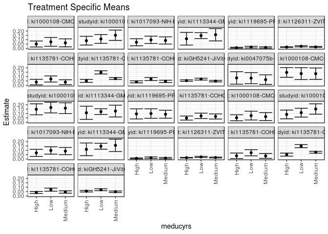

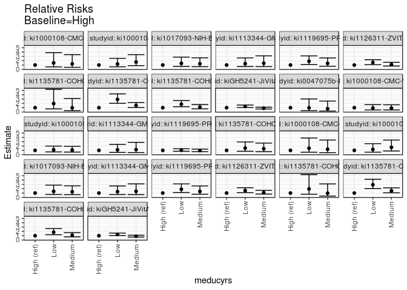

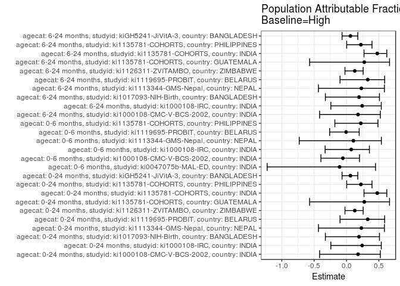

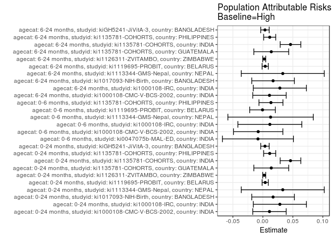

## Results Table

### Parameter: TSM

| agecat | studyid | country | intervention_level | baseline_level | estimate | ci_lower | ci_upper |
| --- | --- | --- | --- | --- | --- | --- | --- |
| 0-24 months | ki1000108-CMC-V-BCS-2002 | INDIA | High | NA | 0.0506329 | 0.0164006 | 0.0848652 |
| 0-24 months | ki1000108-CMC-V-BCS-2002 | INDIA | Low | NA | 0.0754717 | 0.0251181 | 0.1258253 |
| 0-24 months | ki1000108-CMC-V-BCS-2002 | INDIA | Medium | NA | 0.0642202 | 0.0181372 | 0.1103031 |
| 0-24 months | ki1000108-IRC | INDIA | High | NA | 0.0887097 | 0.0386046 | 0.1388147 |
| 0-24 months | ki1000108-IRC | INDIA | Low | NA | 0.1088435 | 0.0584357 | 0.1592514 |
| 0-24 months | ki1000108-IRC | INDIA | Medium | NA | 0.1510791 | 0.0914708 | 0.2106874 |
| 0-24 months | ki1017093-NIH-Birth | BANGLADESH | High | NA | 0.0709677 | 0.0305069 | 0.1114286 |
| 0-24 months | ki1017093-NIH-Birth | BANGLADESH | Low | NA | 0.0984456 | 0.0563758 | 0.1405154 |
| 0-24 months | ki1017093-NIH-Birth | BANGLADESH | Medium | NA | 0.0913978 | 0.0499451 | 0.1328506 |
| 0-24 months | ki1113344-GMS-Nepal | NEPAL | High | NA | 0.1111111 | 0.0384582 | 0.1837641 |
| 0-24 months | ki1113344-GMS-Nepal | NEPAL | Low | NA | 0.1469880 | 0.1128913 | 0.1810846 |
| 0-24 months | ki1113344-GMS-Nepal | NEPAL | Medium | NA | 0.1568627 | 0.0862268 | 0.2274987 |
| 0-24 months | ki1119695-PROBIT | BELARUS | High | NA | 0.0080064 | 0.0026954 | 0.0133174 |
| 0-24 months | ki1119695-PROBIT | BELARUS | Low | NA | 0.0150319 | 0.0054398 | 0.0246241 |
| 0-24 months | ki1119695-PROBIT | BELARUS | Medium | NA | 0.0110783 | 0.0035015 | 0.0186551 |
| 0-24 months | ki1126311-ZVITAMBO | ZIMBABWE | High | NA | 0.0156219 | 0.0121820 | 0.0190617 |
| 0-24 months | ki1126311-ZVITAMBO | ZIMBABWE | Low | NA | 0.0244524 | 0.0176196 | 0.0312851 |
| 0-24 months | ki1126311-ZVITAMBO | ZIMBABWE | Medium | NA | 0.0173508 | 0.0120858 | 0.0226158 |
| 0-24 months | ki1135781-COHORTS | GUATEMALA | High | NA | 0.0370370 | 0.0051488 | 0.0689253 |
| 0-24 months | ki1135781-COHORTS | GUATEMALA | Low | NA | 0.0724638 | 0.0371116 | 0.1078159 |
| 0-24 months | ki1135781-COHORTS | GUATEMALA | Medium | NA | 0.0359281 | 0.0076736 | 0.0641827 |
| 0-24 months | ki1135781-COHORTS | INDIA | High | NA | 0.0508197 | 0.0333887 | 0.0682506 |
| 0-24 months | ki1135781-COHORTS | INDIA | Low | NA | 0.1480978 | 0.1299505 | 0.1662451 |
| 0-24 months | ki1135781-COHORTS | INDIA | Medium | NA | 0.0775544 | 0.0669339 | 0.0881748 |
| 0-24 months | ki1135781-COHORTS | PHILIPPINES | High | NA | 0.0398104 | 0.0280106 | 0.0516103 |
| 0-24 months | ki1135781-COHORTS | PHILIPPINES | Low | NA | 0.0719340 | 0.0545406 | 0.0893273 |
| 0-24 months | ki1135781-COHORTS | PHILIPPINES | Medium | NA | 0.0451542 | 0.0316460 | 0.0586624 |
| 0-24 months | kiGH5241-JiVitA-3 | BANGLADESH | High | NA | 0.0545194 | 0.0457316 | 0.0633071 |
| 0-24 months | kiGH5241-JiVitA-3 | BANGLADESH | Low | NA | 0.0709577 | 0.0604277 | 0.0814877 |
| 0-24 months | kiGH5241-JiVitA-3 | BANGLADESH | Medium | NA | 0.0482180 | 0.0391894 | 0.0572467 |
| 0-6 months | ki0047075b-MAL-ED | INDIA | High | NA | 0.0847458 | 0.0135108 | 0.1559808 |
| 0-6 months | ki0047075b-MAL-ED | INDIA | Low | NA | 0.0821918 | 0.0190352 | 0.1453483 |
| 0-6 months | ki0047075b-MAL-ED | INDIA | Medium | NA | 0.0649351 | 0.0097648 | 0.1201053 |
| 0-6 months | ki1000108-CMC-V-BCS-2002 | INDIA | High | NA | 0.1474359 | 0.0917227 | 0.2031491 |
| 0-6 months | ki1000108-CMC-V-BCS-2002 | INDIA | Low | NA | 0.1340206 | 0.0661301 | 0.2019112 |
| 0-6 months | ki1000108-CMC-V-BCS-2002 | INDIA | Medium | NA | 0.1333333 | 0.0682220 | 0.1984446 |
| 0-6 months | ki1000108-IRC | INDIA | High | NA | 0.1475410 | 0.0845321 | 0.2105499 |
| 0-6 months | ki1000108-IRC | INDIA | Low | NA | 0.1678322 | 0.1065034 | 0.2291609 |
| 0-6 months | ki1000108-IRC | INDIA | Medium | NA | 0.1605839 | 0.0990282 | 0.2221397 |
| 0-6 months | ki1113344-GMS-Nepal | NEPAL | High | NA | 0.1076923 | 0.0322623 | 0.1831223 |
| 0-6 months | ki1113344-GMS-Nepal | NEPAL | Low | NA | 0.1210526 | 0.0882259 | 0.1538794 |
| 0-6 months | ki1113344-GMS-Nepal | NEPAL | Medium | NA | 0.1276596 | 0.0601357 | 0.1951834 |
| 0-6 months | ki1119695-PROBIT | BELARUS | High | NA | 0.0947776 | 0.0369470 | 0.1526082 |
| 0-6 months | ki1119695-PROBIT | BELARUS | Low | NA | 0.0991280 | 0.0447796 | 0.1534765 |
| 0-6 months | ki1119695-PROBIT | BELARUS | Medium | NA | 0.0908827 | 0.0455121 | 0.1362533 |
| 0-6 months | ki1135781-COHORTS | PHILIPPINES | High | NA | 0.0474684 | 0.0240098 | 0.0709269 |
| 0-6 months | ki1135781-COHORTS | PHILIPPINES | Low | NA | 0.0725191 | 0.0410973 | 0.1039409 |
| 0-6 months | ki1135781-COHORTS | PHILIPPINES | Medium | NA | 0.0654545 | 0.0362058 | 0.0947032 |
| 6-24 months | ki1000108-CMC-V-BCS-2002 | INDIA | High | NA | 0.0506329 | 0.0164006 | 0.0848652 |
| 6-24 months | ki1000108-CMC-V-BCS-2002 | INDIA | Low | NA | 0.0754717 | 0.0251181 | 0.1258253 |
| 6-24 months | ki1000108-CMC-V-BCS-2002 | INDIA | Medium | NA | 0.0642202 | 0.0181372 | 0.1103031 |
| 6-24 months | ki1000108-IRC | INDIA | High | NA | 0.0887097 | 0.0386046 | 0.1388147 |
| 6-24 months | ki1000108-IRC | INDIA | Low | NA | 0.1088435 | 0.0584357 | 0.1592514 |
| 6-24 months | ki1000108-IRC | INDIA | Medium | NA | 0.1510791 | 0.0914708 | 0.2106874 |
| 6-24 months | ki1017093-NIH-Birth | BANGLADESH | High | NA | 0.0709677 | 0.0305069 | 0.1114286 |
| 6-24 months | ki1017093-NIH-Birth | BANGLADESH | Low | NA | 0.0984456 | 0.0563758 | 0.1405154 |
| 6-24 months | ki1017093-NIH-Birth | BANGLADESH | Medium | NA | 0.0913978 | 0.0499451 | 0.1328506 |
| 6-24 months | ki1113344-GMS-Nepal | NEPAL | High | NA | 0.1111111 | 0.0384582 | 0.1837641 |
| 6-24 months | ki1113344-GMS-Nepal | NEPAL | Low | NA | 0.1469880 | 0.1128913 | 0.1810846 |
| 6-24 months | ki1113344-GMS-Nepal | NEPAL | Medium | NA | 0.1568627 | 0.0862268 | 0.2274987 |
| 6-24 months | ki1119695-PROBIT | BELARUS | High | NA | 0.0080064 | 0.0026954 | 0.0133174 |
| 6-24 months | ki1119695-PROBIT | BELARUS | Low | NA | 0.0150319 | 0.0054398 | 0.0246241 |
| 6-24 months | ki1119695-PROBIT | BELARUS | Medium | NA | 0.0110783 | 0.0035015 | 0.0186551 |
| 6-24 months | ki1126311-ZVITAMBO | ZIMBABWE | High | NA | 0.0156219 | 0.0121820 | 0.0190617 |
| 6-24 months | ki1126311-ZVITAMBO | ZIMBABWE | Low | NA | 0.0244524 | 0.0176196 | 0.0312851 |
| 6-24 months | ki1126311-ZVITAMBO | ZIMBABWE | Medium | NA | 0.0173508 | 0.0120858 | 0.0226158 |
| 6-24 months | ki1135781-COHORTS | GUATEMALA | High | NA | 0.0370370 | 0.0051488 | 0.0689253 |
| 6-24 months | ki1135781-COHORTS | GUATEMALA | Low | NA | 0.0724638 | 0.0371116 | 0.1078159 |
| 6-24 months | ki1135781-COHORTS | GUATEMALA | Medium | NA | 0.0359281 | 0.0076736 | 0.0641827 |
| 6-24 months | ki1135781-COHORTS | INDIA | High | NA | 0.0508197 | 0.0333887 | 0.0682506 |
| 6-24 months | ki1135781-COHORTS | INDIA | Low | NA | 0.1480978 | 0.1299505 | 0.1662451 |
| 6-24 months | ki1135781-COHORTS | INDIA | Medium | NA | 0.0775544 | 0.0669339 | 0.0881748 |
| 6-24 months | ki1135781-COHORTS | PHILIPPINES | High | NA | 0.0398104 | 0.0280106 | 0.0516103 |
| 6-24 months | ki1135781-COHORTS | PHILIPPINES | Low | NA | 0.0719340 | 0.0545406 | 0.0893273 |
| 6-24 months | ki1135781-COHORTS | PHILIPPINES | Medium | NA | 0.0451542 | 0.0316460 | 0.0586624 |
| 6-24 months | kiGH5241-JiVitA-3 | BANGLADESH | High | NA | 0.0545194 | 0.0457316 | 0.0633071 |
| 6-24 months | kiGH5241-JiVitA-3 | BANGLADESH | Low | NA | 0.0709577 | 0.0604277 | 0.0814877 |
| 6-24 months | kiGH5241-JiVitA-3 | BANGLADESH | Medium | NA | 0.0482180 | 0.0391894 | 0.0572467 |

### Parameter: E(Y)

| agecat | studyid | country | intervention_level | baseline_level | estimate | ci_lower | ci_upper |
| --- | --- | --- | --- | --- | --- | --- | --- |
| 0-24 months | ki1000108-CMC-V-BCS-2002 | INDIA | NA | NA | 0.0616622 | 0.0372186 | 0.0861058 |
| 0-24 months | ki1000108-IRC | INDIA | NA | NA | 0.1170732 | 0.0859146 | 0.1482317 |
| 0-24 months | ki1017093-NIH-Birth | BANGLADESH | NA | NA | 0.0880150 | 0.0639627 | 0.1120673 |
| 0-24 months | ki1113344-GMS-Nepal | NEPAL | NA | NA | 0.1443124 | 0.1159091 | 0.1727157 |
| 0-24 months | ki1119695-PROBIT | BELARUS | NA | NA | 0.0119167 | 0.0046062 | 0.0192272 |
| 0-24 months | ki1126311-ZVITAMBO | ZIMBABWE | NA | NA | 0.0179204 | 0.0152268 | 0.0206140 |
| 0-24 months | ki1135781-COHORTS | GUATEMALA | NA | NA | 0.0510806 | 0.0319354 | 0.0702257 |
| 0-24 months | ki1135781-COHORTS | INDIA | NA | NA | 0.0969241 | 0.0882972 | 0.1055510 |
| 0-24 months | ki1135781-COHORTS | PHILIPPINES | NA | NA | 0.0512273 | 0.0430760 | 0.0593786 |
| 0-24 months | kiGH5241-JiVitA-3 | BANGLADESH | NA | NA | 0.0580495 | 0.0522322 | 0.0638669 |
| 0-6 months | ki0047075b-MAL-ED | INDIA | NA | NA | 0.0765550 | 0.0404216 | 0.1126884 |
| 0-6 months | ki1000108-CMC-V-BCS-2002 | INDIA | NA | NA | 0.1396648 | 0.1037072 | 0.1756225 |
| 0-6 months | ki1000108-IRC | INDIA | NA | NA | 0.1592040 | 0.1233945 | 0.1950135 |
| 0-6 months | ki1113344-GMS-Nepal | NEPAL | NA | NA | 0.1205937 | 0.0930759 | 0.1481115 |
| 0-6 months | ki1119695-PROBIT | BELARUS | NA | NA | 0.0941866 | 0.0454872 | 0.1428859 |
| 0-6 months | ki1135781-COHORTS | PHILIPPINES | NA | NA | 0.0609613 | 0.0448957 | 0.0770269 |
| 6-24 months | ki1000108-CMC-V-BCS-2002 | INDIA | NA | NA | 0.0616622 | 0.0372186 | 0.0861058 |
| 6-24 months | ki1000108-IRC | INDIA | NA | NA | 0.1170732 | 0.0859146 | 0.1482317 |
| 6-24 months | ki1017093-NIH-Birth | BANGLADESH | NA | NA | 0.0880150 | 0.0639627 | 0.1120673 |
| 6-24 months | ki1113344-GMS-Nepal | NEPAL | NA | NA | 0.1443124 | 0.1159091 | 0.1727157 |
| 6-24 months | ki1119695-PROBIT | BELARUS | NA | NA | 0.0119167 | 0.0046062 | 0.0192272 |
| 6-24 months | ki1126311-ZVITAMBO | ZIMBABWE | NA | NA | 0.0179204 | 0.0152268 | 0.0206140 |
| 6-24 months | ki1135781-COHORTS | GUATEMALA | NA | NA | 0.0510806 | 0.0319354 | 0.0702257 |
| 6-24 months | ki1135781-COHORTS | INDIA | NA | NA | 0.0969241 | 0.0882972 | 0.1055510 |
| 6-24 months | ki1135781-COHORTS | PHILIPPINES | NA | NA | 0.0512273 | 0.0430760 | 0.0593786 |
| 6-24 months | kiGH5241-JiVitA-3 | BANGLADESH | NA | NA | 0.0580495 | 0.0522322 | 0.0638669 |

### Parameter: RR

| agecat | studyid | country | intervention_level | baseline_level | estimate | ci_lower | ci_upper |
| --- | --- | --- | --- | --- | --- | --- | --- |
| 0-24 months | ki1000108-CMC-V-BCS-2002 | INDIA | High | High | 1.0000000 | 1.0000000 | 1.000000 |
| 0-24 months | ki1000108-CMC-V-BCS-2002 | INDIA | Low | High | 1.4905660 | 0.5765449 | 3.853624 |
| 0-24 months | ki1000108-CMC-V-BCS-2002 | INDIA | Medium | High | 1.2683486 | 0.4732218 | 3.399481 |
| 0-24 months | ki1000108-IRC | INDIA | High | High | 1.0000000 | 1.0000000 | 1.000000 |
| 0-24 months | ki1000108-IRC | INDIA | Low | High | 1.2269635 | 0.5910402 | 2.547102 |
| 0-24 months | ki1000108-IRC | INDIA | Medium | High | 1.7030739 | 0.8550937 | 3.391980 |
| 0-24 months | ki1017093-NIH-Birth | BANGLADESH | High | High | 1.0000000 | 1.0000000 | 1.000000 |
| 0-24 months | ki1017093-NIH-Birth | BANGLADESH | Low | High | 1.3871879 | 0.6802941 | 2.828616 |
| 0-24 months | ki1017093-NIH-Birth | BANGLADESH | Medium | High | 1.2878788 | 0.6215563 | 2.668514 |
| 0-24 months | ki1113344-GMS-Nepal | NEPAL | High | High | 1.0000000 | 1.0000000 | 1.000000 |
| 0-24 months | ki1113344-GMS-Nepal | NEPAL | Low | High | 1.3228916 | 0.6610114 | 2.647522 |
| 0-24 months | ki1113344-GMS-Nepal | NEPAL | Medium | High | 1.4117647 | 0.6382074 | 3.122934 |
| 0-24 months | ki1119695-PROBIT | BELARUS | High | High | 1.0000000 | 1.0000000 | 1.000000 |
| 0-24 months | ki1119695-PROBIT | BELARUS | Low | High | 1.8774897 | 1.1310584 | 3.116521 |
| 0-24 months | ki1119695-PROBIT | BELARUS | Medium | High | 1.3836780 | 0.7237468 | 2.645352 |
| 0-24 months | ki1126311-ZVITAMBO | ZIMBABWE | High | High | 1.0000000 | 1.0000000 | 1.000000 |
| 0-24 months | ki1126311-ZVITAMBO | ZIMBABWE | Low | High | 1.5652651 | 1.0966855 | 2.234054 |
| 0-24 months | ki1126311-ZVITAMBO | ZIMBABWE | Medium | High | 1.1106753 | 0.7634177 | 1.615891 |
| 0-24 months | ki1135781-COHORTS | GUATEMALA | High | High | 1.0000000 | 1.0000000 | 1.000000 |
| 0-24 months | ki1135781-COHORTS | GUATEMALA | Low | High | 1.9565217 | 0.7272917 | 5.263331 |
| 0-24 months | ki1135781-COHORTS | GUATEMALA | Medium | High | 0.9700599 | 0.3022563 | 3.113305 |
| 0-24 months | ki1135781-COHORTS | INDIA | High | High | 1.0000000 | 1.0000000 | 1.000000 |
| 0-24 months | ki1135781-COHORTS | INDIA | Low | High | 2.9141830 | 2.0245797 | 4.194679 |
| 0-24 months | ki1135781-COHORTS | INDIA | Medium | High | 1.5260699 | 1.0548225 | 2.207849 |
| 0-24 months | ki1135781-COHORTS | PHILIPPINES | High | High | 1.0000000 | 1.0000000 | 1.000000 |
| 0-24 months | ki1135781-COHORTS | PHILIPPINES | Low | High | 1.8069126 | 1.2325721 | 2.648878 |
| 0-24 months | ki1135781-COHORTS | PHILIPPINES | Medium | High | 1.1342301 | 0.7444023 | 1.728203 |
| 0-24 months | kiGH5241-JiVitA-3 | BANGLADESH | High | High | 1.0000000 | 1.0000000 | 1.000000 |
| 0-24 months | kiGH5241-JiVitA-3 | BANGLADESH | Low | High | 1.3015143 | 1.0487265 | 1.615235 |
| 0-24 months | kiGH5241-JiVitA-3 | BANGLADESH | Medium | High | 0.8844202 | 0.6980611 | 1.120531 |
| 0-6 months | ki0047075b-MAL-ED | INDIA | High | High | 1.0000000 | 1.0000000 | 1.000000 |
| 0-6 months | ki0047075b-MAL-ED | INDIA | Low | High | 0.9698630 | 0.3105336 | 3.029090 |
| 0-6 months | ki0047075b-MAL-ED | INDIA | Medium | High | 0.7662338 | 0.2319037 | 2.531715 |
| 0-6 months | ki1000108-CMC-V-BCS-2002 | INDIA | High | High | 1.0000000 | 1.0000000 | 1.000000 |
| 0-6 months | ki1000108-CMC-V-BCS-2002 | INDIA | Low | High | 0.9090094 | 0.4831709 | 1.710157 |
| 0-6 months | ki1000108-CMC-V-BCS-2002 | INDIA | Medium | High | 0.9043478 | 0.4877230 | 1.676864 |
| 0-6 months | ki1000108-IRC | INDIA | High | High | 1.0000000 | 1.0000000 | 1.000000 |
| 0-6 months | ki1000108-IRC | INDIA | Low | High | 1.1375291 | 0.6484305 | 1.995545 |
| 0-6 months | ki1000108-IRC | INDIA | Medium | High | 1.0884023 | 0.6131463 | 1.932034 |
| 0-6 months | ki1113344-GMS-Nepal | NEPAL | High | High | 1.0000000 | 1.0000000 | 1.000000 |
| 0-6 months | ki1113344-GMS-Nepal | NEPAL | Low | High | 1.1240601 | 0.5303929 | 2.382217 |
| 0-6 months | ki1113344-GMS-Nepal | NEPAL | Medium | High | 1.1854103 | 0.4928181 | 2.851352 |
| 0-6 months | ki1119695-PROBIT | BELARUS | High | High | 1.0000000 | 1.0000000 | 1.000000 |
| 0-6 months | ki1119695-PROBIT | BELARUS | Low | High | 1.0459020 | 0.7922714 | 1.380728 |
| 0-6 months | ki1119695-PROBIT | BELARUS | Medium | High | 0.9589052 | 0.7096073 | 1.295786 |
| 0-6 months | ki1135781-COHORTS | PHILIPPINES | High | High | 1.0000000 | 1.0000000 | 1.000000 |
| 0-6 months | ki1135781-COHORTS | PHILIPPINES | Low | High | 1.5277353 | 0.7917928 | 2.947710 |
| 0-6 months | ki1135781-COHORTS | PHILIPPINES | Medium | High | 1.3789091 | 0.7082413 | 2.684665 |
| 6-24 months | ki1000108-CMC-V-BCS-2002 | INDIA | High | High | 1.0000000 | 1.0000000 | 1.000000 |
| 6-24 months | ki1000108-CMC-V-BCS-2002 | INDIA | Low | High | 1.4905660 | 0.5765449 | 3.853624 |
| 6-24 months | ki1000108-CMC-V-BCS-2002 | INDIA | Medium | High | 1.2683486 | 0.4732218 | 3.399481 |
| 6-24 months | ki1000108-IRC | INDIA | High | High | 1.0000000 | 1.0000000 | 1.000000 |
| 6-24 months | ki1000108-IRC | INDIA | Low | High | 1.2269635 | 0.5910402 | 2.547102 |
| 6-24 months | ki1000108-IRC | INDIA | Medium | High | 1.7030739 | 0.8550937 | 3.391980 |
| 6-24 months | ki1017093-NIH-Birth | BANGLADESH | High | High | 1.0000000 | 1.0000000 | 1.000000 |
| 6-24 months | ki1017093-NIH-Birth | BANGLADESH | Low | High | 1.3871879 | 0.6802941 | 2.828616 |
| 6-24 months | ki1017093-NIH-Birth | BANGLADESH | Medium | High | 1.2878788 | 0.6215563 | 2.668514 |
| 6-24 months | ki1113344-GMS-Nepal | NEPAL | High | High | 1.0000000 | 1.0000000 | 1.000000 |
| 6-24 months | ki1113344-GMS-Nepal | NEPAL | Low | High | 1.3228916 | 0.6610114 | 2.647522 |
| 6-24 months | ki1113344-GMS-Nepal | NEPAL | Medium | High | 1.4117647 | 0.6382074 | 3.122934 |
| 6-24 months | ki1119695-PROBIT | BELARUS | High | High | 1.0000000 | 1.0000000 | 1.000000 |
| 6-24 months | ki1119695-PROBIT | BELARUS | Low | High | 1.8774897 | 1.1310584 | 3.116521 |
| 6-24 months | ki1119695-PROBIT | BELARUS | Medium | High | 1.3836780 | 0.7237468 | 2.645352 |
| 6-24 months | ki1126311-ZVITAMBO | ZIMBABWE | High | High | 1.0000000 | 1.0000000 | 1.000000 |
| 6-24 months | ki1126311-ZVITAMBO | ZIMBABWE | Low | High | 1.5652651 | 1.0966855 | 2.234054 |
| 6-24 months | ki1126311-ZVITAMBO | ZIMBABWE | Medium | High | 1.1106753 | 0.7634177 | 1.615891 |
| 6-24 months | ki1135781-COHORTS | GUATEMALA | High | High | 1.0000000 | 1.0000000 | 1.000000 |
| 6-24 months | ki1135781-COHORTS | GUATEMALA | Low | High | 1.9565217 | 0.7272917 | 5.263331 |
| 6-24 months | ki1135781-COHORTS | GUATEMALA | Medium | High | 0.9700599 | 0.3022563 | 3.113305 |
| 6-24 months | ki1135781-COHORTS | INDIA | High | High | 1.0000000 | 1.0000000 | 1.000000 |
| 6-24 months | ki1135781-COHORTS | INDIA | Low | High | 2.9141830 | 2.0245797 | 4.194679 |
| 6-24 months | ki1135781-COHORTS | INDIA | Medium | High | 1.5260699 | 1.0548225 | 2.207849 |
| 6-24 months | ki1135781-COHORTS | PHILIPPINES | High | High | 1.0000000 | 1.0000000 | 1.000000 |
| 6-24 months | ki1135781-COHORTS | PHILIPPINES | Low | High | 1.8069126 | 1.2325721 | 2.648878 |
| 6-24 months | ki1135781-COHORTS | PHILIPPINES | Medium | High | 1.1342301 | 0.7444023 | 1.728203 |
| 6-24 months | kiGH5241-JiVitA-3 | BANGLADESH | High | High | 1.0000000 | 1.0000000 | 1.000000 |
| 6-24 months | kiGH5241-JiVitA-3 | BANGLADESH | Low | High | 1.3015143 | 1.0487265 | 1.615235 |
| 6-24 months | kiGH5241-JiVitA-3 | BANGLADESH | Medium | High | 0.8844202 | 0.6980611 | 1.120531 |

### Parameter: PAR

| agecat | studyid | country | intervention_level | baseline_level | estimate | ci_lower | ci_upper |
| --- | --- | --- | --- | --- | --- | --- | --- |
| 0-24 months | ki1000108-CMC-V-BCS-2002 | INDIA | High | NA | 0.0110293 | -0.0168377 | 0.0388962 |
| 0-24 months | ki1000108-IRC | INDIA | High | NA | 0.0283635 | -0.0159402 | 0.0726672 |
| 0-24 months | ki1017093-NIH-Birth | BANGLADESH | High | NA | 0.0170472 | -0.0185228 | 0.0526173 |
| 0-24 months | ki1113344-GMS-Nepal | NEPAL | High | NA | 0.0332013 | -0.0360426 | 0.1024451 |
| 0-24 months | ki1119695-PROBIT | BELARUS | High | NA | 0.0039103 | -0.0012779 | 0.0090985 |
| 0-24 months | ki1126311-ZVITAMBO | ZIMBABWE | High | NA | 0.0022985 | -0.0002330 | 0.0048300 |
| 0-24 months | ki1135781-COHORTS | GUATEMALA | High | NA | 0.0140435 | -0.0150082 | 0.0430952 |
| 0-24 months | ki1135781-COHORTS | INDIA | High | NA | 0.0461044 | 0.0288930 | 0.0633159 |
| 0-24 months | ki1135781-COHORTS | PHILIPPINES | High | NA | 0.0114169 | 0.0013588 | 0.0214750 |
| 0-24 months | kiGH5241-JiVitA-3 | BANGLADESH | High | NA | 0.0035302 | -0.0035164 | 0.0105767 |
| 0-6 months | ki0047075b-MAL-ED | INDIA | High | NA | -0.0081907 | -0.0674787 | 0.0510972 |
| 0-6 months | ki1000108-CMC-V-BCS-2002 | INDIA | High | NA | -0.0077711 | -0.0489024 | 0.0333602 |
| 0-6 months | ki1000108-IRC | INDIA | High | NA | 0.0116630 | -0.0416541 | 0.0649801 |
| 0-6 months | ki1113344-GMS-Nepal | NEPAL | High | NA | 0.0129014 | -0.0583351 | 0.0841379 |
| 0-6 months | ki1119695-PROBIT | BELARUS | High | NA | -0.0005910 | -0.0219724 | 0.0207904 |
| 0-6 months | ki1135781-COHORTS | PHILIPPINES | High | NA | 0.0134930 | -0.0065240 | 0.0335099 |
| 6-24 months | ki1000108-CMC-V-BCS-2002 | INDIA | High | NA | 0.0110293 | -0.0168377 | 0.0388962 |
| 6-24 months | ki1000108-IRC | INDIA | High | NA | 0.0283635 | -0.0159402 | 0.0726672 |
| 6-24 months | ki1017093-NIH-Birth | BANGLADESH | High | NA | 0.0170472 | -0.0185228 | 0.0526173 |
| 6-24 months | ki1113344-GMS-Nepal | NEPAL | High | NA | 0.0332013 | -0.0360426 | 0.1024451 |
| 6-24 months | ki1119695-PROBIT | BELARUS | High | NA | 0.0039103 | -0.0012779 | 0.0090985 |
| 6-24 months | ki1126311-ZVITAMBO | ZIMBABWE | High | NA | 0.0022985 | -0.0002330 | 0.0048300 |
| 6-24 months | ki1135781-COHORTS | GUATEMALA | High | NA | 0.0140435 | -0.0150082 | 0.0430952 |
| 6-24 months | ki1135781-COHORTS | INDIA | High | NA | 0.0461044 | 0.0288930 | 0.0633159 |
| 6-24 months | ki1135781-COHORTS | PHILIPPINES | High | NA | 0.0114169 | 0.0013588 | 0.0214750 |
| 6-24 months | kiGH5241-JiVitA-3 | BANGLADESH | High | NA | 0.0035302 | -0.0035164 | 0.0105767 |

### Parameter: PAF

| agecat | studyid | country | intervention_level | baseline_level | estimate | ci_lower | ci_upper |
| --- | --- | --- | --- | --- | --- | --- | --- |
| 0-24 months | ki1000108-CMC-V-BCS-2002 | INDIA | High | NA | 0.1788663 | -0.4151376 | 0.5235371 |
| 0-24 months | ki1000108-IRC | INDIA | High | NA | 0.2422715 | -0.2413087 | 0.5374620 |
| 0-24 months | ki1017093-NIH-Birth | BANGLADESH | High | NA | 0.1936857 | -0.3261632 | 0.5097566 |
| 0-24 months | ki1113344-GMS-Nepal | NEPAL | High | NA | 0.2300654 | -0.4328814 | 0.5862886 |
| 0-24 months | ki1119695-PROBIT | BELARUS | High | NA | 0.3281362 | -0.0996129 | 0.5894910 |
| 0-24 months | ki1126311-ZVITAMBO | ZIMBABWE | High | NA | 0.1282622 | -0.0235894 | 0.2575863 |
| 0-24 months | ki1135781-COHORTS | GUATEMALA | High | NA | 0.2749288 | -0.5698040 | 0.6650994 |
| 0-24 months | ki1135781-COHORTS | INDIA | High | NA | 0.4756756 | 0.2706642 | 0.6230596 |
| 0-24 months | ki1135781-COHORTS | PHILIPPINES | High | NA | 0.2228673 | 0.0032918 | 0.3940702 |
| 0-24 months | kiGH5241-JiVitA-3 | BANGLADESH | High | NA | 0.0608130 | -0.0684126 | 0.1744087 |
| 0-6 months | ki0047075b-MAL-ED | INDIA | High | NA | -0.1069915 | -1.2256042 | 0.4493944 |
| 0-6 months | ki1000108-CMC-V-BCS-2002 | INDIA | High | NA | -0.0556410 | -0.3950202 | 0.2011743 |
| 0-6 months | ki1000108-IRC | INDIA | High | NA | 0.0732582 | -0.3297719 | 0.3541371 |
| 0-6 months | ki1113344-GMS-Nepal | NEPAL | High | NA | 0.1069822 | -0.7296280 | 0.5389293 |
| 0-6 months | ki1119695-PROBIT | BELARUS | High | NA | -0.0062747 | -0.2599523 | 0.1963277 |
| 0-6 months | ki1135781-COHORTS | PHILIPPINES | High | NA | 0.2213364 | -0.1799720 | 0.4861599 |
| 6-24 months | ki1000108-CMC-V-BCS-2002 | INDIA | High | NA | 0.1788663 | -0.4151376 | 0.5235371 |
| 6-24 months | ki1000108-IRC | INDIA | High | NA | 0.2422715 | -0.2413087 | 0.5374620 |
| 6-24 months | ki1017093-NIH-Birth | BANGLADESH | High | NA | 0.1936857 | -0.3261632 | 0.5097566 |
| 6-24 months | ki1113344-GMS-Nepal | NEPAL | High | NA | 0.2300654 | -0.4328814 | 0.5862886 |
| 6-24 months | ki1119695-PROBIT | BELARUS | High | NA | 0.3281362 | -0.0996129 | 0.5894910 |
| 6-24 months | ki1126311-ZVITAMBO | ZIMBABWE | High | NA | 0.1282622 | -0.0235894 | 0.2575863 |
| 6-24 months | ki1135781-COHORTS | GUATEMALA | High | NA | 0.2749288 | -0.5698040 | 0.6650994 |
| 6-24 months | ki1135781-COHORTS | INDIA | High | NA | 0.4756756 | 0.2706642 | 0.6230596 |
| 6-24 months | ki1135781-COHORTS | PHILIPPINES | High | NA | 0.2228673 | 0.0032918 | 0.3940702 |
| 6-24 months | kiGH5241-JiVitA-3 | BANGLADESH | High | NA | 0.0608130 | -0.0684126 | 0.1744087 |